# Vignette for Library ‘safetydata’

Pericles

2017-06-21

## Introduction

> “It’s not the fall that kills you, it’s the sudden stop.” (Douglas Adams)

Data analysis is a growing field within aviation safety. The United States’ civil aviation authority, the Federal Aviation Administration, requires large commercial operators to develop and operate a Safety Management System as outlined in [14 CFR §5](https://www.ecfr.gov/cgi-bin/text-idx?SID=31a1ff34c5fb23bfab62b105fa038ceb&mc=true&node=pt14.1.5&rgn=div5) and has issued guidance on how to comply with the regulation through [Advisory Circular 120-92](https://www.faa.gov/regulations_policies/advisory_circulars/index.cfm/go/document.information/documentID/1026670). In both the regulation and the Advisory Circular, data management is mentioned several times, but data analysis techniques and best practices are still a work in progress. The ‘safetydata’ library is a R package to help aviation safety data analysts perform common tasks.

## Datasets

The following datasets are currently available:

- **AirportCodes_20170404** contains ICAO and IATA codes for various airports
- **AirportTimezones_20170404** contains timezones for various airports
- **NTSBData_20170328** is a copy of the NTSB accidents and incidents database created with the **downloadNTSBdf** function
- **USA_DaylightSavings_20170404** is a dataframe with USA daylight savings adjustments for the decade starting 2010

## Functions

The following functions are currently available:

- **densityAltitude** is a function that calculates density altitude using the National Weather Service method and data points that are commonly available to pilots and airlines.
- **downloadNTSBdf** is a function that downloads the NTSB accidents and incidents database as a R data.frame. This function can take some time to run, so the **NTSBData_20170328** dataset is available as pre-downloaded static copy.
- **qq_abline_intersect** and **qq_abline_slope** are helpful when checking for the normality of data. They are intended to be used with [ggplot2](http://ggplot2.tidyverse.org/).
- **EAS_to_TAS** and **TAS_to_GS** are functions used to convert between common aircraft speeds.
- **spcChart** is a function that plots np-charts or p-charts using calculations from the qcc library and graphics from the [ggplot2](http://ggplot2.tidyverse.org/) library.
- **windVectors_crosswind** and **windVectors_headwind** are functions used to extract the longitudinal and transverse vectors of wind relative to an aircraft.

## Examples

Combine several functions to determine ground speed from raw aircraft data.

```r
library(safetydata)

heading <- 048 # aircraft true heading in bearing degrees
wind_from <- 290 # wind direction (from) in bearing degrees
wind_speed <- 12 # wind speed in knots
temperature <- 26 # outside air temperature in degrees Celcius
dewpoint <- 10 # dewpoint in degrees Celcius
altimeter <- 29.90 # altimeter in inches of mercury
airspeed <- 280 # airspeed in equivalent airspeed knots

# Calculate true airspeed
TAS <- EAS_to_TAS(airspeed, altimeter, temperature)

# Calculate headwind
headwind <- windVectors_headwind(heading, wind_from, wind_speed)

# Calculate ground speed
GS <- TAS_to_GS(TAS, headwind)

# Print results
TAS
```

```
## [1] 285.3887
```

```r
headwind
```

```
## [1] -5.633659
```

```r
GS
```

```
## [1] 291.0223
```

Create statistical process control p- and np-charts. Note that this function is currently built to work with .CSV files since data is commonly extracted from other systems. The function expects cretain specific formatting in the .CSV file and can be quite picky.

```r
library(safetydata)
library(tidyverse)
```

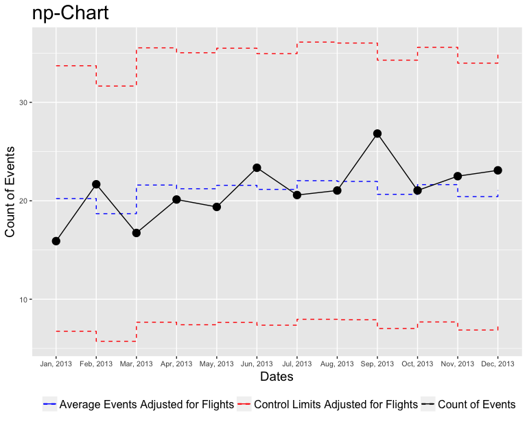

```r
library(nycflights13)
set.seed(78345)

# Create a .CSV file with formatting appropriate for this function
flights %>%
  group_by(month) %>%
  summarise(Operations = n()) %>%
  ungroup() %>%
  mutate(Deficiencies = rnorm(12, mean = 20, sd = 5)) %>% # Note: The "deficiencies" for this are pseudo-randomly created
  mutate(month = month.abb[month]) %>%
  mutate(Date = paste(month, 2013, sep = ", ")) %>%
  select(Date,
         Deficiencies,
         Operations) %>%
  write_csv(path = paste(getwd(), "example.csv", sep = "/"))

# np-chart
spcChart("example.csv", title = "np-Chart", type = "np", startdate = as.Date("2013-01-01"), enddate = as.Date("2013-12-31"))
```

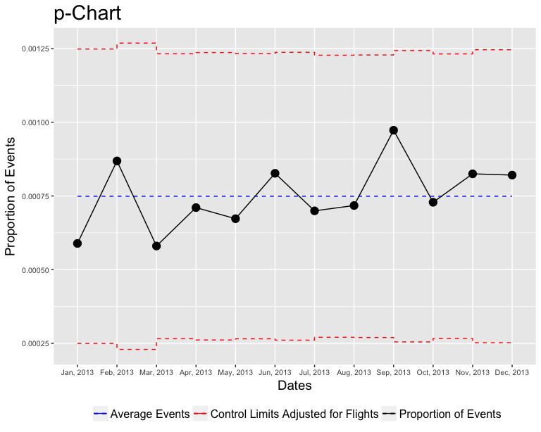

```r
# p-chart
spcChart("example.csv", title = "p-Chart", type = "p", startdate = as.Date("2013-01-01"), enddate = as.Date("2013-12-31"))
```

Plot actual vs. theoretical normal distribution quantiles to check for normality of data. In the example below, the sample does not come from a normally distributed dataset.

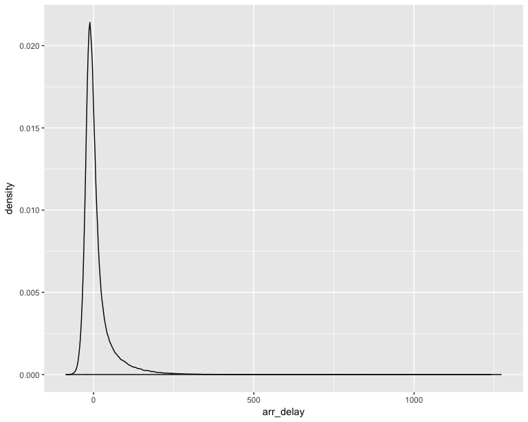

```r
library(safetydata)
library(tidyverse)
library(nycflights13)
set.seed(78345)

# Use density plot or histogram to review the data visually
flights %>%
  ggplot(mapping = aes(x = arr_delay)) + geom_density()
```

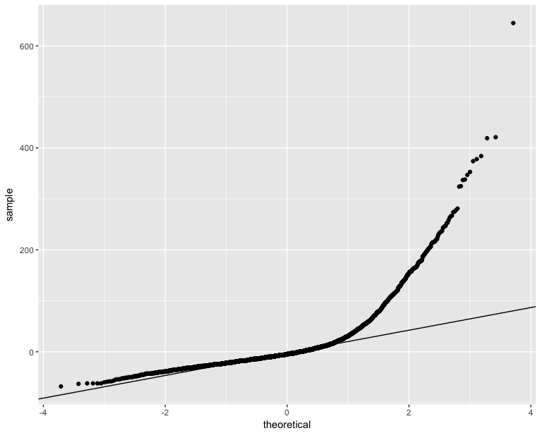

```r
# Use the Q_Q plot to support conclusions from the distribution plot
data <- flights %>%
  select(arr_delay) %>%
  sample_n(5000) %>%
  unlist()

ggplot(data = NULL, mapping = aes(sample = data)) +
  geom_qq() +
  geom_abline(slope = qq_abline_slope(data), intercept = qq_abline_intersect(data))
```

```r
# Back up Q-Q plot with a Shapiro-Wilk test
flights %>%
  select(arr_delay) %>%
  sample_n(5000) %>%
  unlist() %>%
  shapiro.test()
```

```
##
##  Shapiro-Wilk normality test
##
## data:  .
## W = 0.70157, p-value < 2.2e-16
```